# Analiza ocjena i prodaje videoigara

- Show All Code
- Hide All Code
- View Source

Seminar iz kolegija Statistički praktikum

Author

Tibor Milković

# 1 Uvod

Industrija videoigara danas ostvaruje veće prihode od filmske i glazbene industrije. Godišnje izlaze tisuće naslova, a samo mali dio njih ostvari veliku prodaju. Zato nas zanima što razlikuje uspješne igre od neuspješnih.

Metacritic je stranica koja recenzije profesionalnih kritičara agregira u jednu ocjenu na skali 0-100, a uz to prikuplja i ocjene običnih igrača. Te ocjene mogu imati financijske posljedice: studio Obsidian Entertainment nije dobio ugovoreni bonus jer je igra Fallout: New Vegas dobila ocjenu 84, jedan bod ispod ugovorenog praga od 85.[^1]

Metacritic ocjene utječu na kupovne odluke, stoga je prirodno pitati slaže li se publika s kritikom i prodaju li se bolje ocijenjene igre stvarno bolje.

U ovom radu pokušat ćemo odgovoriti na sljedeća pitanja:

- Kakve su ocjene i prodaja videoigara općenito?
- Slažu li se kritičari i publika u ocjenama istih igara?
- Razlikuju li se žanrovi po kvaliteti?
- Prodaju li se bolje ocijenjene igre bolje?

# 2 Opis varijabli

Izvor naše baze podataka: stranica Kaggle, “Video Game Sales With Ratings”, koja kombinira podatke s izvora vgchartz i Metacritic, a uključene su samo igre s mjerljivom prodajom (najmanje 10.000 primjeraka).

Analizu provodimo na skupu od 16.719 igara iz baze, koja odražava stanje na dan 22. prosinca 2016. godine. Izvorna baza sadrži 16 varijabli, no za analizu koristimo sljedeće:

- **Name** - kvalitativna nominalna varijabla - ime videoigre
- **Genre** - kvalitativna nominalna varijabla - žanr videoigre
- **Global_Sales** - numerička neprekidna varijabla - broj prodanih kopija na globalnom tržištu (u milijunima)
- **Log_Sales** - numerička neprekidna varijabla (izvedena) - log10 varijable **Global_Sales**
- **Critic_Score** - numerička neprekidna varijabla - ocjena kritičara na skali od 0-100 prema Metacritic konvenciji
- **User_Score** - numerička neprekidna varijabla - ocjena običnih igrača na skali 0-10
- **User_Score100** - numerička neprekidna varijabla (izvedena) - ocjena običnih igrača na skali 0-100
- **Hit** - kvalitativna nominalna (binarna) varijabla (izvedena) - označava je li igra prodana u više od milijun primjeraka (TRUE/FALSE)

## 2.1 Napomene

U analizi se koristimo prvenstveno žanrom, globalnom prodajom te ocjenama kritike i korisnika.

Polaznu bazu podataka izmijenili smo i prilagodili analizi:

- u varijabli **User_Score** neki su podaci bili obilježeni s “tbd” (to be determined), stoga smo te vrijednosti pretvorili u NA vrijednosti. Tada smo stvorili novu varijablu, **User_Score100** koja se nalazi na skali 0-100 tako što smo pomnožili prethodnu varijablu (**User_Score***10)
- varijabla **Log_Sales** nastala je budući da je distribucija prodaje asimetrična s desnim repom (nekoliko megahitova, većina igara s malom prodajom)  
  logaritamska transformacija čini je simetričnijom i time prikladnijom za korelaciju i linearnu regresiju
- ocjene tretiramo kao neprekidne numeričke varijable zbog velikog raspona vrijednosti
- Za analize koje uključuju ocjene koristi se podskup igara koje imaju i ocjenu kritike i ocjenu korisnika, a takvih je u skupu 7.017
- Za dvije igre žanr nije naveden u bazi pa su te vrijednosti tretirane kao nedostajuće

# 3 Analiza podataka

## 3.1 Distribucija prodaje

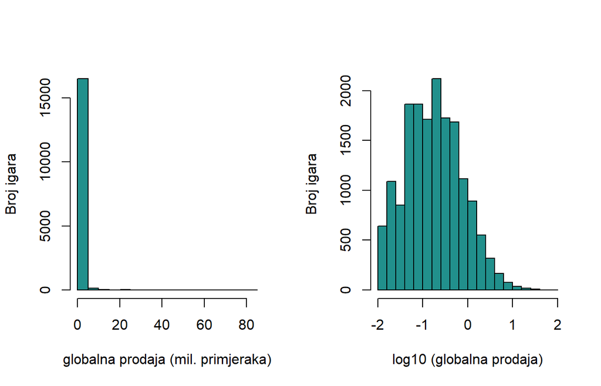

Slika 1: Distribucija globalne prodaje (lijevo) i log-transformirane prodaje (desno)

```r
par(mfrow = c(1,2))


hist(podaci$Global_Sales, xlab = "globalna prodaja (mil. primjeraka)",ylab="Broj igara", main="", col=viridis(1, begin=0.5))
hist(podaci$Log_Sales, xlab = "log10 (globalna prodaja)", ylab="Broj igara", main ="", col = viridis(1, begin=0.5))
```

Vidljivo je da je distribucija asimetrična s desnim repom, odnosno velika se većina igara proda u manje od milijun primjeraka, a nekoliko megahitova rasteže rep do ~82.5 milijuna.

Zbog toga izvodimo novu varijablu koja logaritamski transformira globalne prodaje, a na grafu se može uočiti da je distribucija približno simetrična.

U analizama povezanosti prodaje s ocjenama koristit ćemo Log_Sales.

```r
#fivenum(podaci$Global_Sales)

GS <- podaci$Global_Sales

stat_prodaja <- data.frame(
  Minimum = min(GS),
  Medijan = median(GS),
  Prosjek = round(mean(GS), 2),
  Maksimum = max(GS)

)

#stat_prodaja
knitr::kable(stat_prodaja) #uredniji prikaz za pdf
```

Tablica 1: Osnovne statistike globalne prodaje

| Minimum | Medijan | Prosjek | Maksimum |
| --- | --- | --- | --- |
| 0.01 | 0.17 | 0.53 | 82.53 |

Tipična igra u skupu prodaje se u oko 0.17 milijuna primjeraka, dok je prosjek znatno veći i iznosi 0.53 milijuna. Ta razlika posljedica je asimetrične distribucije. Nekoliko igara s vrlo velikom prodajom povlači prosjek prema gore pa medijan bolje opisuje tipičnu igru u skupu. Raspon je golem, od minimalnih 0.01 do 82.53 milijuna, koliko je prodala najprodavanija igra u skupu, Wii Sports.

## 3.2 Žanrovi i ocjene

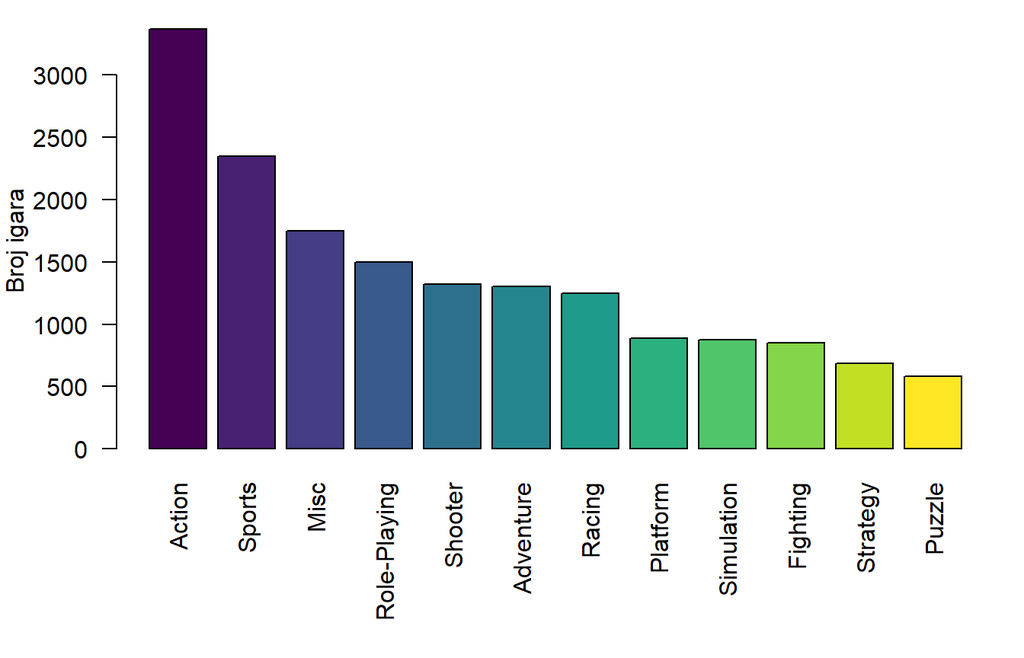

Slika 2: Broj igara po žanru

```r
par(mar = c(7, 4, 1, 1))

freq <- sort(table(podaci$Genre), dec=T)

boje_zanr <- setNames(viridis(length(freq)), names(freq))

barplot(freq, col=viridis(12), ylab="Broj igara", las=2)
```

Najzastupljeniji žanr u skupu je Action s 3370 igara, slijede Sports i Misc, dok je najmanje zastupljen Puzzle.

Zanima nas i razlikuju li se žanrovi po kvaliteti pa promatramo distribucije ocjena kritike po žanrovima.

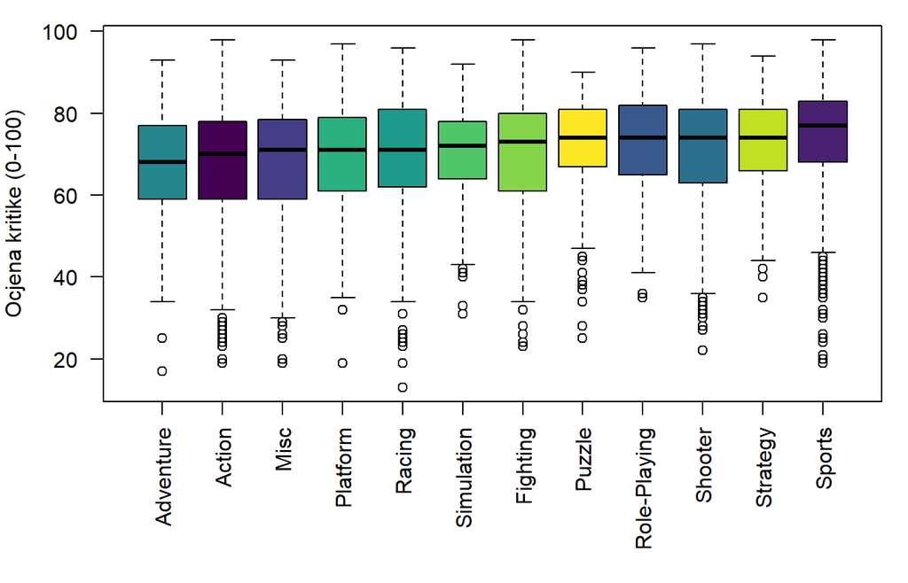

Slika 3: Ocjena kritike po žanru

Najviši medijan ocjene kritike ima žanr Sports, a najniži Adventure. Uočimo da najveće raspršenje ocjena kritike imaju žanrovi Misc, Racing te Action, u kojem su izvrsne i vrlo loše ocijenjene igre - dok su Simulation i Strategy najujednačeniji.

Jesu li uočene razlike između žanrova statistički značajne, provjeravamo u nastavku.

## 3.3 Jesu li akcijske igre u prosjeku “generalno pozitivne”?

Koristit ćemo t-test na jednom uzorku jer uspoređujemo očekivanje jedne populacije (akcijske igre) s referentnom vrijednošću.  
Metacritic prag 75 (“generally favorable”) stvarna je referentna vrijednost, stoga usporedba s njom ima smisla. Uzorak je velik pa je test opravdan prema centralnom graničnom teoremu (CGT).

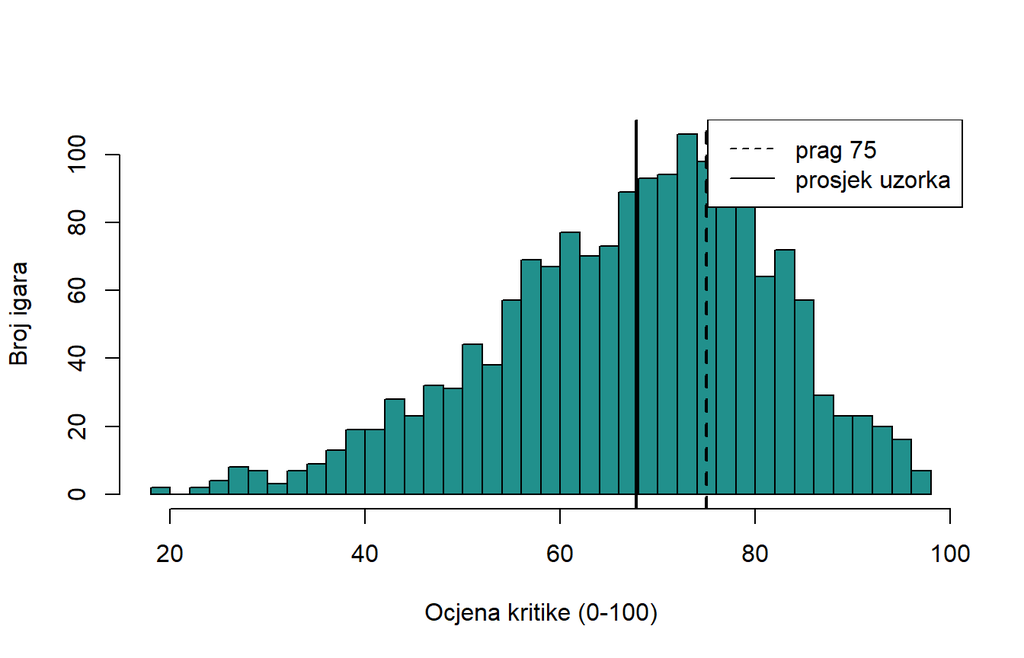

Slika 4: Distribucija ocjene kritike akcijskih igara

Označimo s $\mu$ očekivanu ocjenu kritike akcijskih igara.

Hipoteze:

- $H_0: \mu = 75$
- $H_1: \mu < 75$

Dobivena p-vrijednost < 2.2e-16 => p-vrijednost < 0.05; na razini značajnosti 0.05 odbacujemo $H_0$, tj. možemo tvrditi da je očekivana ocjena kritike akcijskih igara manja od 75. Prosječna ocjena u uzorku iznosi ~68, oko 7 bodova ispod praga.

## 3.4 Razlikuju li se žanrovi Action i Sports?

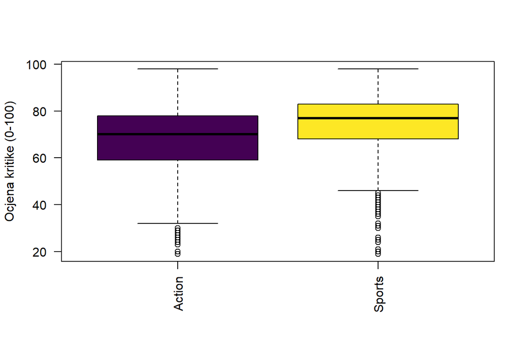

Slika 5: Ocjena kritike za žanrove Action i Sports

Označimo:

- $\mu_1$ - očekivana ocjena kritike žanra Action
- $\mu_2$ - očekivana ocjena kritike žanra Sports

Hipoteze:

- $H_0: \mu_1 = \mu_2$
- $H_1: \mu_1 \ne \mu_2$

U svakoj su grupi različite igre, nema uparivanja i stoga ih smatramo nezavisnim uzorcima. Za provjeru hipoteze koristit ćemo Welchov test jer ne pretpostavlja jednake varijance grupa - klasični Studentov t bi tražio provjeru jednakosti varijanci kao dodatnu pretpostavku.

Dobivena p-vrijednost < 2.2e-16 => p-vrijednost < 0.05; na razini značajnosti 0.05 odbacujemo $H_0$, tj. možemo tvrditi da se očekivane ocjene kritike žanrova Action i Sports razlikuju, pri čemu sportske igre imaju višu prosječnu ocjenu (~74 naspram ~68).

## 3.5 Slažu li se kritičari i publika?

Ovdje se radi o uparenim uzorcima jer uspoređujemo dvije ocjene iste igre. Usporedbu omogućuje varijabla User_Score100, kojom su obje ocjene na istoj skali.

Označimo s $\mu_p$ očekivanu razliku ocjene kritike i ocjene korisnika za istu igru.

Hipoteze:

- $H_0: \mu_p = 0$
- $H_1: \mu_p \ne 0$

Dobivena p-vrijednost < 2.2e-16 => p-vrijednost < 0.05; na razini značajnosti 0.05 odbacujemo $H_0$ i prihvaćamo $H_1$, tj. možemo tvrditi da je očekivana razlika ocjene kritike i korisnika za istu igru različita od 0.

Prosječna razlika iznosi ~ -1.57, što znači da kritičari istim igrama daju niže ocjene - dakle publika i kritika se sustavno razilaze u tom smjeru.

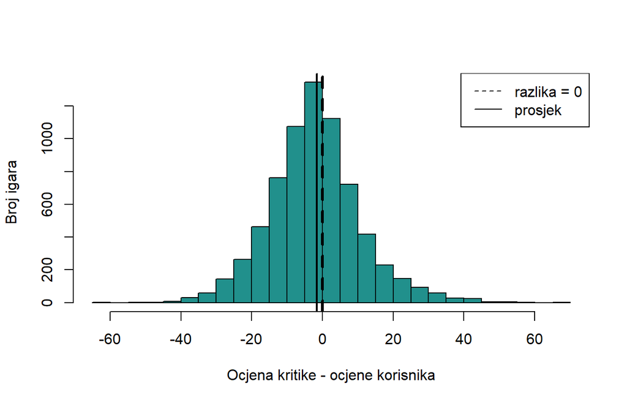

Slika 6: Distribucija razlike ocjena (kritika - korisnici)

Distribucija razlike pomaknuta je ulijevo od nule, što potvrđuje da kritika u prosjeku strože ocjenjuje.

Prosječna razlika od 1.57 bodova statistički je značajna. Uz ovako velik uzorak (n = 7.017) i male razlike postaju značajne. Raspršenje je pritom veliko: za pojedine igre ocjene kritike i publike razilaze se i za više od 60 bodova.

## 3.6 Prodaju li se bolje ocijenjene igre bolje?

### 3.6.1 Udio hitova prema ocjeni kritike

Za razliku od dosadašnjih usporedbi očekivanja, ovdje uspoređujemo udjele - ‘Hit’ je binarna varijabla (TRUE/FALSE) pa nema smisla računati prosjek ocjena, nego proporciju hitova u svakoj skupini. Skupine (igre s ocjenom $\geq 75$ i ostale) čine dva nezavisna uzorka, a oba su dovoljno velika za korištenje testa o usporedbi proporcija.

Igru smatramo hitom ako je prodana u više od milijun primjeraka; visoko ocijenjenima smatramo igre s ocjenom kritike od najmanje 75.

Označimo:

- $\theta_1$ - proporcija hitova među visoko ocijenjenim igrama (ocjena $\geq$ 75)
- $\theta_2$ - proporcija hitova među ostalim igrama

Hipoteze:

- $H_0: \theta_1 = \theta_2$
- $H_1: \theta_1 > \theta_2$

P-vrijednost < 2.2e-16 => p-vrijednost < 0.05, na razini značajnosti od 0.05 odbacujemo $H_0$ tj. možemo tvrditi da je proporcija hitova veća među visoko ocijenjenim igrama.

Među visoko ocijenjenim igrama hit je otprilike svaka treća (32%), dok je među ostalima hitova tek 9%.

### 3.6.2 Povezanost ocjena i prodaje

Koristimo Log_Sales umjesto Global_Sales. Test o koeficijentu korelacije pretpostavlja dvodimenzionalnu normalnu distribuciju, a bez te pretpostavke može se koristiti na velikom uzorku ako distribucije nisu jako asimetrične. Izvorna prodaja jako je asimetrična s desnim repom (dominiraju megahitovi) pa koristimo logaritamski transformiranu prodaju, čija je distribucija približno simetrična.

Promatramo korelaciju ocjene kritike i log-prodaje.

Hipoteze (gdje je $\rho$ koeficijent korelacije ocjene kritike i log-prodaje):

- $H_0$ : $\rho = 0$
- $H_1$ : $\rho$ $\ne 0$

Dobivena p-vrijednost < 2.2e-16 => p-vrijednost < 0.05 pa na razini značajnosti od 0.05 odbacujemo $H_0$ i prihvaćamo $H_1$, odnosno možemo tvrditi da je korelacija između ocjene kritike i log-prodaje statistički značajno različita od nule.

Pearsonov koeficijent korelacije, kao procjena za $\rho$, iznosi r = 0.36 - procijenjena povezanost je pozitivna, ali slaba do umjerena.

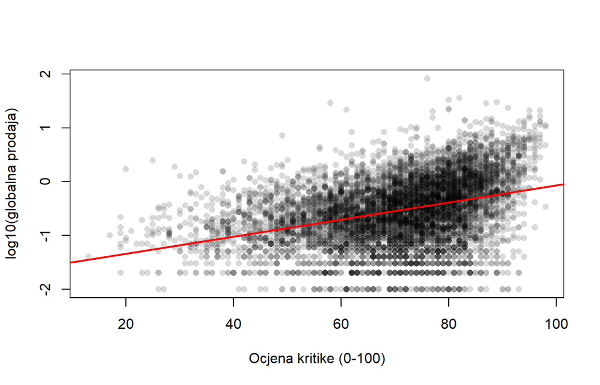

Slika 7: Odnos ocjene kritike i log-prodaje

```r
plot(podaci_oc$Critic_Score, podaci_oc$Log_Sales,
     pch = 16, col = rgb(0,0,0,0.15),
     xlab="Ocjena kritike (0-100)", ylab="log10(globalna prodaja)")

abline(lm(podaci_oc$Log_Sales ~ podaci_oc$Critic_Score), col="red", lwd=2)
```

### 3.6.3 Regresijski model prodaje

Procijenjeni model glasi: Log_Sales = $b_0 + b_1 \cdot$Critic_Score.

**Analiza adekvatnosti modela**: koeficijent uz ocjenu kritike statistički je značajan (p-vrijednost < 2.2e-16) i iznosi $b_1 \approx 0.016$. Budući da je zavisna varijabla log10 prodaje, koeficijent tumačimo na sljedeći način:

porast ocjene za 10 bodova množi očekivanu prodaju s $10^{10 \cdot b_1} \approx 1.44$ - igra s 10 bodova višom ocjenom u prosjeku ostvaruje oko 1.44x (44%) veću prodaju.

**Analiza jakosti modela**: $R^2 = 0.13$ pokazuje da model objašnjava samo oko 13% varijabilnosti log-prodaje. Ocjena kritike je dakle slab prediktor prodaje; kvaliteta igre povezana je s komercijalnim uspjehom, no sama ga po sebi ne jamči.

Primijetimo da je $R^2 = 0.13$ upravo kvadrat koeficijenta korelacije iz prethodnog odjeljka ($0.36^2 \approx 0.13$), budući da oba opisuju istu linearnu vezu.

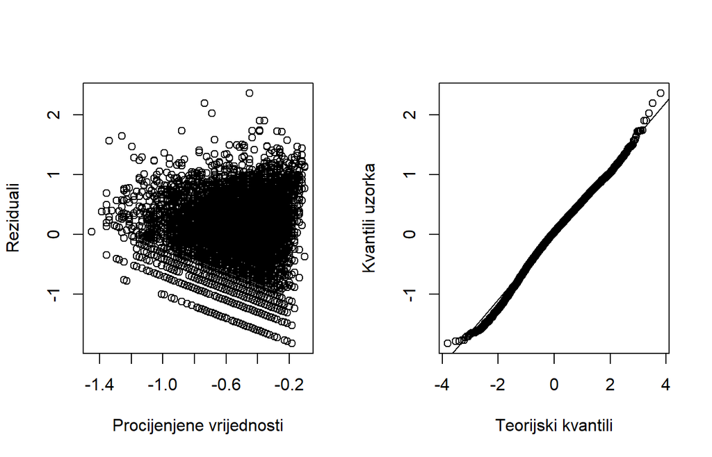

Slika 8: Analiza reziduala: reziduali u ovisnosti o procijenjenim vrijednostima (lijevo) i QQ-plot reziduala (desno)

Na grafu reziduala u ovisnosti o procijenjenim vrijednostima ne uočava se sustavno povećanje ni smanjenje raspršenja pa nema razloga sumnjati u homogenost varijanci grešaka. QQ-plot pokazuje da reziduali u središnjem dijelu dobro prate normalnu distribuciju, uz blaga odstupanja u repovima, što uz ovako velik uzorak ne ugrožava zaključke.

Nezavisnost grešaka ne provjeravamo grafovima uzastopnih reziduala jer opažanja nisu vremenski niz, nego međusobno različite igre. Formalni Shapiro-Wilkov test normalnosti nije primjenjiv jer je u R-u ograničen na uzorke do 5000 opažanja.

# 4 Zaključak

U ovom radu analizirali smo ocjene i prodaju videoigara u skupu od 16.719 naslova, s ciljem odgovora na pitanja postavljena u uvodu. Distribucija prodaje pokazala se vrlo asimetričnom s desnim repom; tipična igra prodaje se u oko 0.17 milijuna primjeraka, dok rijetki megahitovi poput najprodavanije igre Wii Sports (~82.5 mil.) rastežu raspon.

Prosječna razlika ocjena statistički je značajna, ali praktično mala: kritika za istu igru u prosjeku daje ocjenu nižu za oko 1.57 bodova. Međutim, raspršenje je veliko i za pojedine igre ocjene se razilaze i do 66 bodova pa prosječno slaganje skriva znatna pojedinačna neslaganja. Žanrovi se pritom značajno razlikuju po kvaliteti: primjerice, sportske igre u prosjeku su ocijenjene oko 6 bodova bolje od akcijskih, koje kao najzastupljeniji žanr ostaju značajno ispod praga “generalno pozitivne” ocjene.

Bolje ocijenjene igre doista se i bolje prodaju: udio hitova među visoko ocijenjenim igrama iznosi ~32% naspram ~9% među ostalima, a korelacija ocjene kritike i log-prodaje je pozitivna (r = 0.36). Regresijski model pokazuje da ocjena kritike objašnjava oko 13% varijabilnosti log-prodaje pa je sama po sebi slab prediktor prodaje.

Za kraj navodimo ograničenja analize. Baza odražava stanje na dan 22. prosinca 2016. godine i uključuje samo igre s mjerljivom prodajom (najmanje 10.000 primjeraka). Analize ocjena provedene su na podskupu od 7.017 igara koje imaju obje ocjene, a to su pretežno veći i noviji naslovi pa zaključci ne vrijede nužno za sve igre. Utvrđene povezanosti opisuju korelaciju, a ne uzročnost.

# 5 Literatura

- https://quarto.org/docs/authoring/markdown-basics.html
- https://dplyr.tidyverse.org/reference/na_if.html
- https://www.kaggle.com/datasets/rush4ratio/video-game-sales-with-ratings?resource=download
- https://www.eurogamer.net/obsidian-fallout-new-vegas-deal-with-bethesda-meant-bonus-payment-only-with-85-metacritic
- https://cran.r-project.org/web/packages/viridisLite/index.html

## Footnotes

[^1]: https://www.eurogamer.net/obsidian-fallout-new-vegas-deal-with-bethesda-meant-bonus-payment-only-with-85-metacritic